# A regionalized SUNY Impact Assessment

## How well do skills of local SUNY graduates match regional labor market needs?

An important dimension of any public university’s impact is whether the skills of their graduates match labor market demand. By comparing the types degrees held by alums as a percent of total regional jobs requiring a related degree (this data comes from the NY Department of Labor via the Rockefeller Center) to SUNY alums as a percent of total regional graduates (the dashed reference line), the series of bar plots below depict this skills (mis)match.

Overall, there is an impressive consistency between SUNY graduates’ skills and regional labor market demand. But there are some notable mismatches. In all cases, there is an oversupply of agricultural and art degrees. The largest and most consistent undersupply is in hospitality. Mohawk Valley, Long Island, and Western New York appear to have the least perfect relationship between skills supplied and skills demanded.

Because of how significant alums are to Mohawk Valley’s labor pool, the skills mismatch in business, healthcare, education, law and public service, and social services is likely constraining economic growth in this region most dramatically.

```r
#load Skills Match Data from CSV file
skills <- read_csv("suny_skills_match_by_region.csv")
```

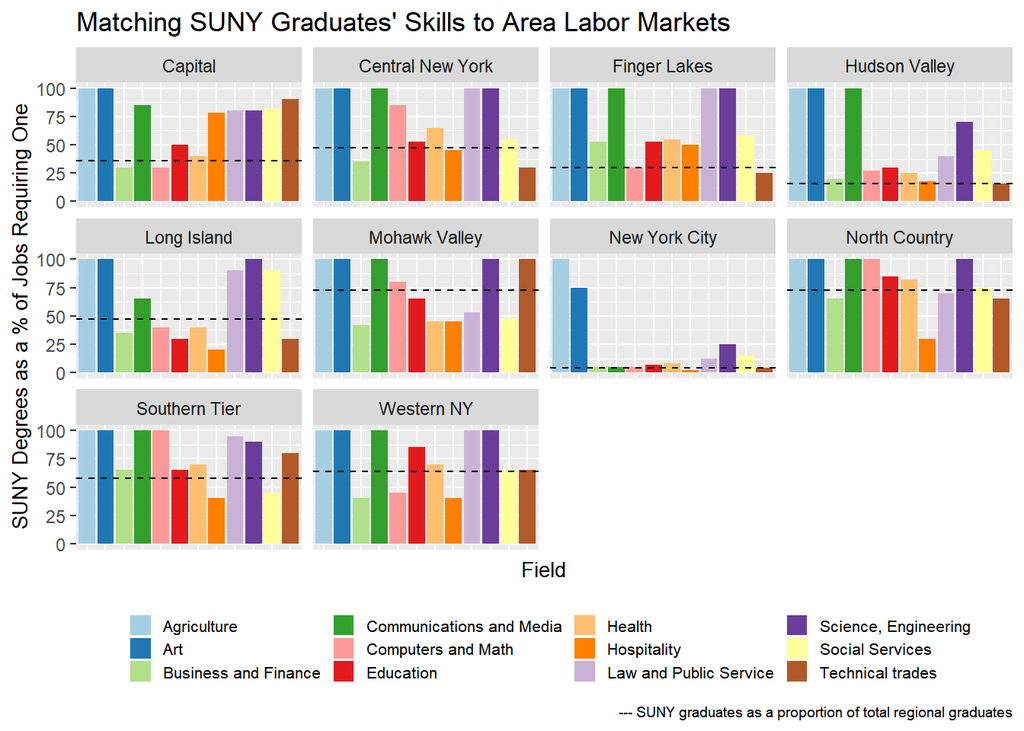

```r
ggplot(skills) +
  geom_col(aes(x = Field , y = Degrees, fill = Field),
           position = "dodge")+
  scale_fill_brewer(palette = "Paired")+
  labs(x = "Field",
       y = "SUNY Degrees as a % of Jobs Requiring One",
       caption = "--- SUNY graduates as a proportion of total regional graduates")+
  theme(axis.text.x = element_blank(),
        axis.ticks.x = element_blank()
        )+
  geom_hline(aes(yintercept = Percent),
             col = "Black", linetype = "dashed")+
  facet_wrap(~Region)+
  theme(legend.position = "bottom",
        legend.box = "horizontal",
        legend.text = element_text(size = 8),
        legend.key.size = unit(0.4, "cm"),
        legend.title = element_blank(),
        plot.caption = element_text(size = 7),
        axis.title.x = element_text(size = 10),
        axis.title.y = element_text(size = 10)
        )+
  ggtitle("Matching SUNY Graduates' Skills to Area Labor Markets")
```

## Regional Education Attainment and Income

There is abundant evidence that the social returns to education exceed the private returns, as higher educational attainment rates lead to productivity and wage gains for the entire workforce (Moretti 2004, 2012).  
Between 2005 and 2017, New York State’s median educational attainment and income rates have consistently exceeded national rates. But there is some variation within the state.

```r
regional_ed <- read_csv("suny_regional_education_tidy.csv")
```

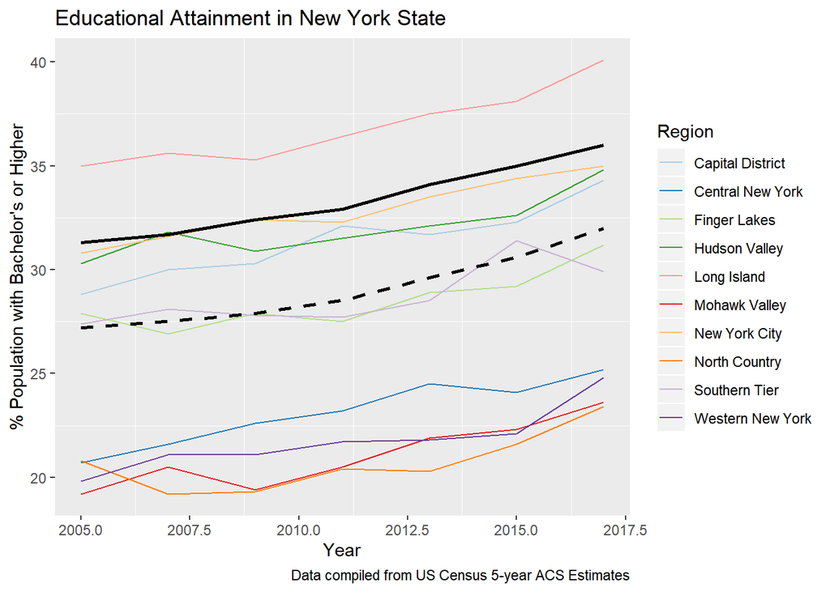

```r
#isolate NY and USA

NY <- regional_ed %>%
  filter(Region == "NY State")

USA <- regional_ed %>%
  filter(Region == "USA")

regional_ed1 <- regional_ed %>%
  filter(Region != "NY State") %>%
  filter(Region != "USA")

#plot education rates in each region

plot <- ggplot(data = regional_ed1,
       aes(x = Year,
           y = bach_or_higher,
           col = Region))+ geom_line()+
  scale_color_brewer(palette = "Paired")

plot + geom_line(data = NY,
                 aes(x = Year, y = bach_or_higher),
                 col = "Black", size = 1)+
  geom_line(data = USA,
            aes(x = Year, y = bach_or_higher),
            col = "Black", linetype = "dashed", size = 1)+
  theme(panel.grid.major = element_blank())+
  labs(x = "Year",
       y = "% Population with Bachelor's or Higher",
       title = "Educational Attainment in New York State",
       caption = "Data compiled from US Census 5-year ACS Estimates"
         )
```

```r
#load income data from .csv file
regional_income <- read_csv("suny_regional_income_data_tidy.csv")
#View data
View(regional_income)
colnames(regional_income)
```

```
## [1] "Region" "Year"   "Income"
```

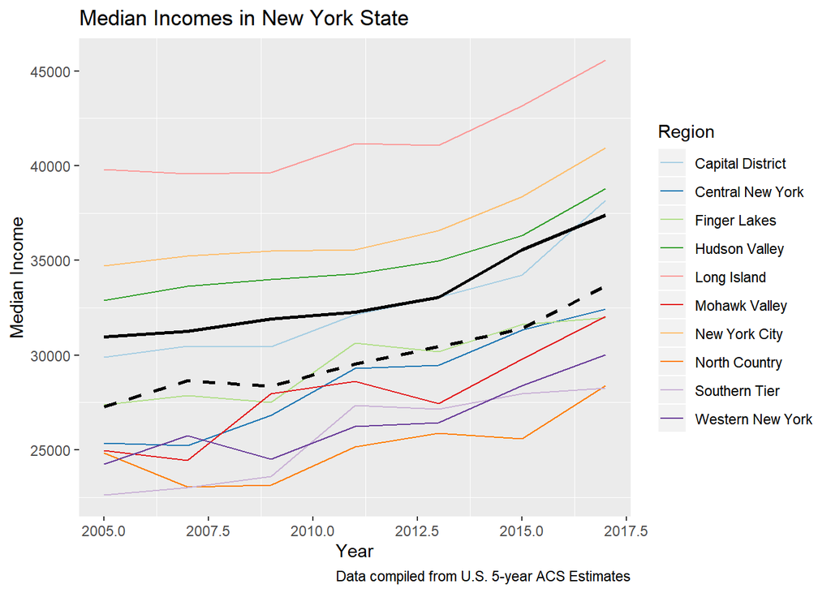

```r
#isolate NY and USA

NY <- regional_income %>%
  filter(Region == "NY State")

USA <- regional_income%>%
  filter(Region == "USA")

regional_income1 <- regional_income %>%
  filter(Region != "NY State") %>%
  filter(Region != "USA")

#build line graphs by year, with NY and USA as reference lines

base_plot <- ggplot(data = regional_income1,
       aes(x = Year, y = Income, col = Region))+
  geom_line()

#add NY State and USA as reference lines

base_plot +
  geom_line(data = NY,
            aes(x = Year, y = Income),
            col= "Black", size = 1)+
  scale_color_brewer(palette = "Paired")+
  geom_line(data = USA,
            aes(x = Year, y = Income),
            col = "Black", linetype="dashed", size = 1)+
  theme(panel.grid.major = element_blank())+
  labs(x = "Year",
       y = "Median Income",
       title = "Median Incomes in New York State",
       caption = "Data compiled from U.S. 5-year ACS Estimates"
         )
```

## Conclusion

The SUNY system’s ability to attract, shape, and retain human capital varies between regions.

The system facilitates resident access through the strategic placement of the institutions themselves, and by offering a range of programs of study at various levels of depth.